# Censored Data Analysis HW 5

Samuel Messa

December 16, 2019

## Data prep

We begin by loading the dataset and necessary libraries.

The dataset includes 101 observations and three variables. The observations are acute lymphatic leukemia patients who had undergone bone a marrow transplant. The variable *time* contains the duration in months since transplantation to either death/relapse or end of follow up, whichever occured first. The outcome of interest is time to death or relapse of ALL (relapse-free survival). The variable *delta* includes the event indicator (1 = death or relapse, 0 = censoring). The variable *type* distinguishes two different types of transplant (1 = allogeneic, 2 = autologous).

```r
load(url("http://karlin.mff.cuni.cz/~vavraj/cda/data/km_all.RData"))
library(ggfortify)
library(survival)
library(survminer)
library(flexsurv)
library(tidyverse)
library(ggpubr)
library(magrittr)
library(knitr)
library(FHtest)
library(muhaz)
library(assertthat)
```

# Task 1

In task 1 we begin by constructing a table, which will be used to calculate the test statistic used in the logrank test. This value will then be compared with the outputs of the functions *survdiff* and *FHtestrcc*.

```r
logrank_stats_table <- all %>%
  group_by(time) %>%
  summarise(
    d_j = sum(delta),
    censored = n() - d_j,
    d_1_j = sum(delta * (type == 1)),
    censored_1 = sum(type == 1) - d_1_j
    ) %>%
  mutate(
    j = 1:n(),
    y_j = rev(cumsum(rev(d_j+censored))),
    y_1_j = rev(cumsum(rev(d_1_j+censored_1))),
    e_j = d_j*(y_1_j/y_j),
    d_1_j_diff_e_j = d_1_j - e_j,
    v_j = d_j * y_1_j * (y_j - y_1_j) * ( y_j - d_j)/( y_j**2 * (y_j-1))
    )
logrank_stats_table %>%
  head(10) %>%
  knitr::kable(escape = FALSE)
```

| time | d_j | censored | d_1_j | censored_1 | j | y_j | y_1_j | e_j | d_1_j_diff_e_j | v_j |
| --- | --- | --- | --- | --- | --- | --- | --- | --- | --- | --- |
| 0.030 | 1 | 0 | 1 | 0 | 1 | 101 | 50 | 0.4950495 | 0.5049505 | 0.2499755 |
| 0.493 | 1 | 0 | 1 | 0 | 2 | 100 | 49 | 0.4900000 | 0.5100000 | 0.2499000 |
| 0.658 | 1 | 0 | 0 | 0 | 3 | 99 | 48 | 0.4848485 | -0.4848485 | 0.2497704 |
| 0.822 | 1 | 0 | 0 | 0 | 4 | 98 | 48 | 0.4897959 | -0.4897959 | 0.2498959 |
| 0.855 | 1 | 0 | 1 | 0 | 5 | 97 | 48 | 0.4948454 | 0.5051546 | 0.2499734 |
| 1.184 | 1 | 0 | 1 | 0 | 6 | 96 | 47 | 0.4895833 | 0.5104167 | 0.2498915 |
| 1.283 | 1 | 0 | 1 | 0 | 7 | 95 | 46 | 0.4842105 | 0.5157895 | 0.2497507 |
| 1.414 | 1 | 0 | 0 | 0 | 8 | 94 | 45 | 0.4787234 | -0.4787234 | 0.2495473 |
| 1.480 | 1 | 0 | 1 | 0 | 9 | 93 | 45 | 0.4838710 | 0.5161290 | 0.2497399 |
| 1.776 | 1 | 0 | 1 | 0 | 10 | 92 | 44 | 0.4782609 | 0.5217391 | 0.2495274 |

```r
self_calculated_unnormed_statistic <- sum(-logrank_stats_table$d_1_j_diff_e_j)
self_calculated_variance <- sum(logrank_stats_table$v_j,na.rm = TRUE)

self_calculated_statistic <- self_calculated_unnormed_statistic/sqrt(self_calculated_variance)
self_calculated_statistic_squared <- self_calculated_statistic**2

survdiff_fit <- all %>% survdiff(formula = Surv(time,delta)~type)
fhttest_fit <- all %>% FHtestrcc(formula = Surv(time,delta)~type,data = .)
```

Asserting whether the self calculated and function-given statistics are the same.

```r
are_equal(self_calculated_statistic_squared,survdiff_fit$chisq)
```

```
## [1] TRUE
```

```r
are_equal(self_calculated_statistic,fhttest_fit$statistic[[1]])
```

```
## [1] TRUE
```

# Task 2 (Plotting)

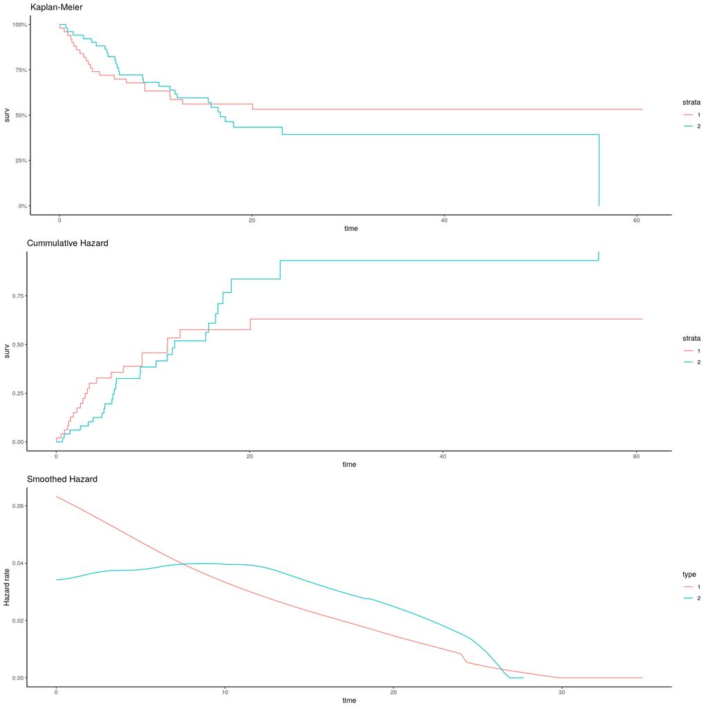

```r
surv_fit <- survfit(formula = Surv(time,delta)~type,conf.type=NULL,data = all)
km <- surv_fit %>% autoplot(data = all,conf.int=FALSE,censor = FALSE) +
  theme_classic() +
  ggtitle("Kaplan-Meier")
ch <- surv_fit %>% autoplot(data = all,conf.int=FALSE,censor = FALSE,fun = "cumhaz") +
  theme_classic() +
  ggtitle("Cummulative Hazard")
haz_type_1 = muhaz(all %>% filter(type == 1) %>% pull(time),all %>% filter(type == 1) %>% pull(delta))
haz_type_2 = muhaz(all %>% filter(type == 2) %>% pull(time),all %>% filter(type == 2) %>% pull(delta))
smooth_haz <- rbind(
    tibble(
      time = haz_type_1$est.grid,
      value = haz_type_1$haz.est,
      type ="1"
      ),
    tibble(
      time = haz_type_2$est.grid,
      value = haz_type_2$haz.est,
      type ="2"
      )
    )
smoothed_haz <- smooth_haz %>%
  ggplot() +
  geom_line(aes(x = time, y = value, color = type))+
  ylab("Hazard rate")+
  theme_classic() +
  ggtitle("Smoothed Hazard")
ggarrange(km,ch,smoothed_haz,nrow = 3)
```

# Task 2 (Tests)

Next we present the p-values corresponding to the

- Logrank,
- Prentice-Wilcoxon
- G(0,1) Fleming-Harrington tests.

None, besides the last rejects the null of equal hazards at the significance level alpha = 0.05. As the figures above suggest, none of them might be paticularly suitable to detect this type of null violation. However, if a decision would have to be made as to the test’s suitability, the logrank test might be best given the lack of other information.

```r
data.frame(
  Logrank = survdiff(formula  = Surv(time,delta)~type,data=all)$chisq %>% pchisq(df=1, lower.tail = F),
  `Prentice Wilcoxon` = survdiff(formula  = Surv(time,delta)~type,data=all, rho = 1)$chisq %>% pchisq(df=1, lower.tail = F),
  `G(0,1) Fleming Harrington` = FHtestrcc(formula = Surv(time,delta)~type,data = all, rho = 0, lambda = 1)$pvalue,
  row.names = c("P-Value")
) %>% knitr::kable()
```

|  | Logrank | Prentice.Wilcoxon | G.0.1..Fleming.Harrington |
| --- | --- | --- | --- |
| P-Value | 0.5367646 | 0.9771244 | 0.0403619 |